## Reproducible research Week 2 - Course Project 1

### 1 Loading and preprocessing the data

```r
data <- read.csv("C:/Users/gate/Documents/coursera/reproducible_research/week2/repdata%2Fdata%2Factivity/activity.csv")
```

```r
summary(data)
```

```
##      steps                date          interval
##  Min.   :  0.00   2012-10-01:  288   Min.   :   0.0
##  1st Qu.:  0.00   2012-10-02:  288   1st Qu.: 588.8
##  Median :  0.00   2012-10-03:  288   Median :1177.5
##  Mean   : 37.38   2012-10-04:  288   Mean   :1177.5
##  3rd Qu.: 12.00   2012-10-05:  288   3rd Qu.:1766.2
##  Max.   :806.00   2012-10-06:  288   Max.   :2355.0
##  NA's   :2304     (Other)   :15840
```

### 2 What is mean total number of steps taken per day?

**1. Histogram of the total number of steps taken each day**

```r
#install.packages("magrittr")
require(magrittr)
#install.packages("dplyr")
require(dplyr)
```

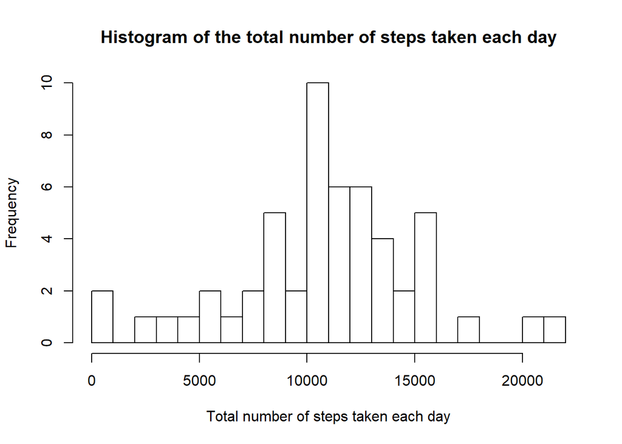

```r
date_data <- data %>% select(date, steps) %>% group_by(date) %>%
    summarize(tsteps= sum   (steps)) %>%na.omit()
hist(date_data$tsteps, xlab = "Total number of steps taken each day",main="Histogram of the total number of steps taken each day", breaks = 20)
```

**2. Calculate and report the mean and median total number of steps taken per day**

```r
mean(date_data$tsteps)
```

```
## [1] 10766.19
```

```r
median(date_data$tsteps)
```

```
## [1] 10765
```

### 3 What is the average daily activity pattern?

**1. Make a time series plot (i.e. type = “l”) of the 5-minute interval (x-axis) and the average number of steps taken, averaged across all days (y-axis)**

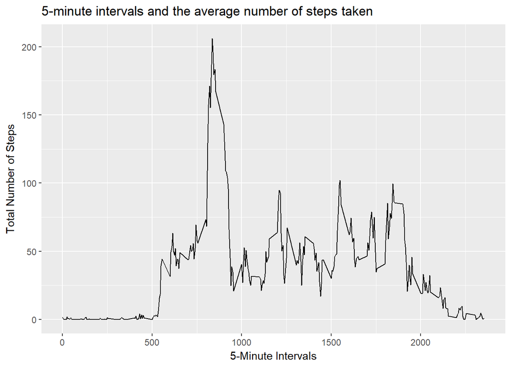

```r
#install.packages("ggplot2")
require(ggplot2)
five_minute <- aggregate(steps ~ interval, data = data, FUN =mean)
graph1 <- ggplot(data = five_minute, aes(x = interval, y = steps)) +
    geom_line() +
    xlab("5-Minute Intervals") +
    ylab("Total Number of Steps") +
    ggtitle("5-minute intervals and the average number of steps taken")
print(graph1)
```

**2. Which 5-minute interval, on average across all the days in the dataset, contains the maximum number of steps?**

```r
five_minute[which(five_minute$steps == max(five_minute$steps)),]
```

```
##     interval    steps
## 104      835 206.1698
```

### 4 Imputing missing values

**1. Calculate and report the total number of missing values in the dataset (i.e. the total number of rows with NAs)**

```r
sapply(X = data, FUN = function(x) sum(is.na(x)))
```

```
##    steps     date interval
##     2304        0        0
```

**2. Devise a strategy for filling in all of the missing values in the dataset. The strategy does not need to be sophisticated. For example, you could use the mean/median for that day, or the mean for that 5-minute interval, etc.** & **3. Create a new dataset that is equal to the original dataset but with the missing data filled in.**

Using the mean for that 5-minute interval to replace the missing values:

```r
#install.packages("magrittr")
require(magrittr)
#install.packages("dplyr")
require(dplyr)
```

```r
replace_na <- function(x) replace(x, is.na(x), mean(x, na.rm = TRUE))
mean_data <- data%>% group_by(interval) %>% mutate(steps= replace_na(steps))
head(mean_data)
```

```
## Source: local data frame [6 x 3]
## Groups: interval [6]
##
##       steps       date interval
##       <dbl>     <fctr>    <int>
## 1 1.7169811 2012-10-01        0
## 2 0.3396226 2012-10-01        5
## 3 0.1320755 2012-10-01       10
## 4 0.1509434 2012-10-01       15
## 5 0.0754717 2012-10-01       20
## 6 2.0943396 2012-10-01       25
```

**4. Make a histogram of the total number of steps taken each day and Calculate and report the mean and median total number of steps taken per day. Do these values differ from the estimates from the first part of the assignment? What is the impact of imputing missing data on the estimates of the total daily number of steps?**

Creating a dataset with total number of steps taken per day:

```r
total_day <- aggregate(mean_data$steps, by=list(mean_data$date), sum)

names(total_day)[1] <- "date"
names(total_day)[2] <- "totalsteps"
summary(total_day)
```

```
##          date      totalsteps
##  2012-10-01: 1   Min.   :   41
##  2012-10-02: 1   1st Qu.: 9819
##  2012-10-03: 1   Median :10766
##  2012-10-04: 1   Mean   :10766
##  2012-10-05: 1   3rd Qu.:12811
##  2012-10-06: 1   Max.   :21194
##  (Other)   :55
```

Histogram of the total number of steps taken each day:

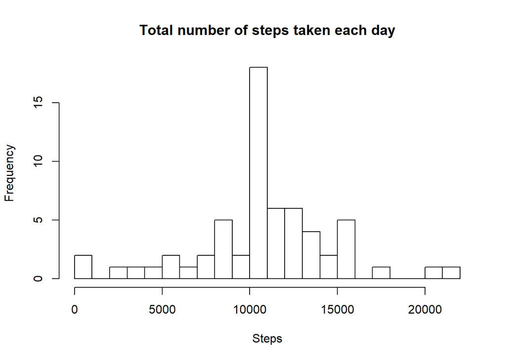

```r
hist(total_day$totalsteps, xlab = "Steps", ylab = "Frequency", main = "Total number of steps taken each day", breaks = 20)
```

Comparing the histograms before/after imputing missing data:

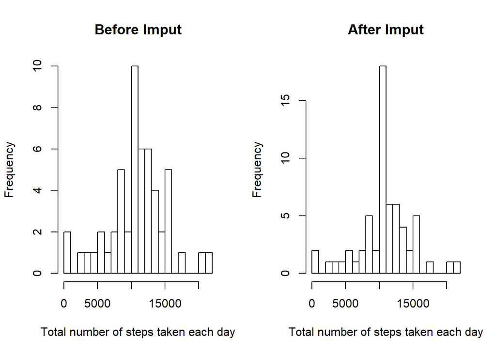

```r
par(mfrow=c(1,2))

hist(date_data$tsteps, xlab = "Total number of steps taken each day",main="Before Imput", breaks = 20)
hist(total_day$totalsteps, xlab = "Total number of steps taken each day", ylab = "Frequency", main = "After Imput", breaks = 20)
```

Comparing the mean and median before/after imputing missing data:

```r
mean_before <- mean(date_data$tsteps, na.rm = TRUE)
mean_after <- mean(total_day$totalsteps)
median_before <- median(date_data$tsteps, na.rm = TRUE)
median_after <- median(total_day$totalsteps)
```

Means:

```r
mean_before
```

```
## [1] 10766.19
```

```r
mean_after
```

```
## [1] 10766.19
```

Medians:

```r
median_before
```

```
## [1] 10765
```

```r
median_after
```

```
## [1] 10766.19
```

### 5 Are there differences in activity patterns between weekdays and weekends?

```r
mean_data$date <- as.Date(mean_data$date)
mean_data$weekday <- weekdays(mean_data$date)
mean_data$weekend <- ifelse(mean_data$weekday=="Saturday" | mean_data$weekday=="Sunday", "Weekend", "Weekday" )

mean_data_week_weekend <- aggregate(mean_data$steps , by= list(mean_data$weekend, mean_data$interval), na.omit(mean))
names(mean_data_week_weekend) <- c("weekend", "interval", "steps")
```

```r
#install.packages("ggplot2")
require(ggplot2)
```

[figure not shown]

```r
ggplot(mean_data_week_weekend, aes(x=interval, y=steps, color=weekend)) + geom_line()+
facet_grid(weekend ~.) + xlab("Interval") + ylab("Mean of Steps") +
    ggtitle("Comparison of Average Number of Steps in Each Interval")
```